# Industry News

Vol. 70

J.H AHN

2022-06-16

## 잡설

이제 바쁨의 한 고비가 넘어간듯 합니다.

회사일의 바쁨이 남아있지만 그래도 일신상의 바쁨을 넘길 수 있어서 다행입니다.

드디어 70호입니다. 느낌이… ‘어쭈 좀 오래 버틴다?’ 입니다. 😄

### 하나 - 4680

불과 수년 전 정책을 입안하고 실행하는 이들이 생각했을 때 전기차는 보급이 안 될거라 생각했다고 합니다.  
정책적으로 친환경을 외쳐도 움직여야 할 이들이 믿음이 없었던 것이죠.  
그렇게 미적거리는 동안 테슬라는 엄청난 속도로 나아가버렸습니다.

테슬라가 4680 배터리 양산을 올해 하겠다고 공언하는 판국에 아직도 ‘전기차는 아직…’ 이라면서 의심의 눈초리를 보내고 있습니다.  
테슬라의 4680으로 몇 년 내로 한국의 배터리 업계도 타격을 받을 수 밖에 없을 것입니다.

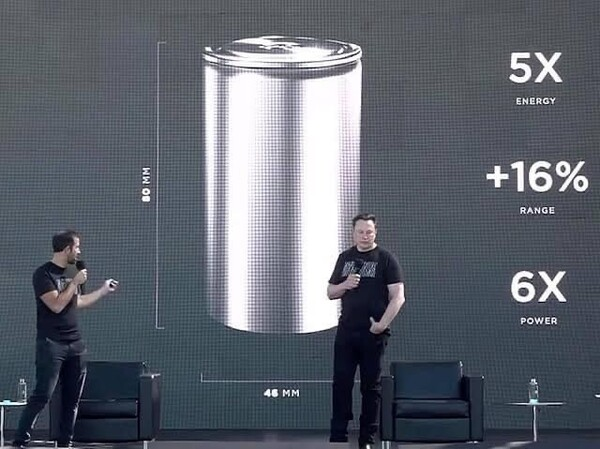

### 둘 - 애플

불과 수년 전 애플이 자사 칩을 개발한다고 했을 때, 다들 부정적으로 바라보았습니다.  
남들이 모두 온라인 판매로 가는 와중에 세계 주요도시에 오프라인 매장을 세웠습니다.  
혁신은 끝났다고 물어뜯었죠.  
결론은 다들 아실 겁니다.

[figure not shown]

한국의 서해은 조수간만의 차가 크고 풍속의 변화가 심해 풍력발전에 적절치 않다고 합니다.  
한국의 동해는 수심이 깊어 설치비가 많이 들어 풍력발전에 적절치 않다고 합니다.  
한국은 산지가 많고 일조량이 적어 태양광이 적절치 않다고 합니다.

만약 산업화 전이었다면…

한국은 질좋은 석탄광산이 없기 때문에 석탄 화력은 적절치 않다고 했을 것이며,  
한국은 우라늄을 수입해야 하기 때문에 원자력 발전은 적절치 않다고 했을 것입니다.

지난 일주일 내내 일본의 조력발전이 [해외 뉴스](https://www.sciencealert.com/japan-s-dropping-a-kaiju-sized-turbine-into-the-ocean-to-fish-for-limitless-energy)를 뒤덮고 있는데도 그 누구도 우리도 해 보자는 이야기가 없습니다.

안될거 같고, 아닌 것 같은 것을 해보는 시도가 없으면서 우리는 왜 달리지 않냐고 불평만 하는 것 같습니다.  
빠르게 달리는 방법은 두 가지 입니다.

느린 차에서 뛰어내린 후, 빠르게 달리는 차에 올라타는 방법과  
**내 차를 빠르게 가도록 만드는 방법** 이 있습니다.

## 새로운 소식들

### Japan Is Dropping a Gargantuan Turbine Into The Ocean to Harness ‘Limitless’ Energy

지난 주 허접스런 BEX같은 로봇이 온갖 언론을 도배하더니, 이번 주에는 조력발전 뉴스가 해외 에너지 매체를 도배했습니다.  
일본의 영향력 때문인지 한국의 소식과는 차원이 다른 수준으로 기사가 나옵니다.

[기사링크](https://www.sciencealert.com/japan-s-dropping-a-kaiju-sized-turbine-into-the-ocean-to-fish-for-limitless-energy)

Ishikawajima-Harima Heavy Industries(우리가 IHI로 부르는 그 회사가 맞습니다.)는 2017년에 NEDO(New Energy and Industrial Technology Development Organization)와 협력하여 설계를 테스트했으며, 현재 10년 넘게 이 기술을 수정해 왔다고 합니다.

지난 2월 일본 남서부 연안 해역에서 3년반에 걸친 현장테스트를 완료했다고 합니다.

[figure not shown]

[figure not shown]

330톤 의 프로토타입 은 ’해류’로 번역되는 단어인 카이류(Kairyu)라고 불리며, 그 구조는 20미터(66피트) 길이의 동체 옆에 비슷한 크기의 한 쌍의 실린더로 구성되어 있고, 각 실린더에는 11미터 길이의 터빈 블레이드에 부착된 발전 시스템이 설치되어 있다고 합니다.

앵커 라인과 전원 케이블로 해저에 연결되면 장치가 스스로 방향을 지정하여 심해 해류를 밀어 전력을 생성하고 이를 그리드로 보낼 수 있는 가장 효율적인 위치를 찾을 수 있다고 설명하고 있습니다.

Kairyu는 파도 아래 약 50미터를 호버링하도록 설계되었고, 2~4노트(초당 약 1~2미터)의 흐름에서 Kairyu는 총 100킬로와트의 전력을 생산할 수 있는 것으로 밝혀졌습니다.

기사의 마지막에 적어둔 것과 같이 *Compared with an average offshore wind turbine’s 3.6 megawatts, it might seem like small sparks. But with demonstrated success at withstanding what nature can throw at it, Kairyu could soon have a monster sibling swinging 20-meter-long turbines to generate a more respectable 2 megawatts.* 평균 3.6MW를 생산하는 것과 비교하면 별 것 아닌 것처럼 보이지만 곧 20m 길이의 블레이드를 달고 2MW 출력을 내는 괴물을 볼 수 있을 것입니다.

이러한 시도와 홍보, 지원이 우리에게도 절실합니다.

덧.) 병원에서 관련 정보 찾아보니 이런 기술은 에너지 밀도가 낮다는 의견이 많았습니다. 그리고 국내에서도 몇 일 후 기사화가 되었습니다.

### 韓 전력이용효율 30년간 나홀로 ‘뒷걸음’

[기사링크](http://www.e2news.com/news/articleView.html?idxno=242797)

지난 번 신재생에너지를 경직성 전원이라 했던 바로 그 기자분입니다. (아직도 수정하지 않으셨네요…)

전력원단위가 우리가 OECD중 꼴찌이니 신재생에 투자하지 말고 에너지 효율에 신경써야 한다는 메시지를 던지고 있습니다.

[figure not shown]

뭐…. 할 말이 많지만 전력 요금은 사람마다 생각하는 바가 다르기 때문에 이런 분이 이런 기사를 썼다 정도로 소개만 하겠습니다.

이런 기사를 열심히 실어나르며, 기자가 언급한 것처럼 전기요금이 비싸지 않아서 혹은 내려서 이렇게 되었다고 주장하실 분들이 있을까 걱정스럽네요.

신재생한다고 할 때는 전기요금 올리면 한국 산업계가 무너지는 것처럼 이야기 하던 사람들이 이젠 전기 요금을 내려서 문제다? 제조업의 전기 사용 비중을 크지 않다? 고 이야기 하니 참으로 혼란스럽네요.

### Milestones for green hydrogen in the USA

[기사링크](https://www.modernpowersystems.com/features/featuremilestones-for-green-hydrogen-in-the-usa-9763067/)

미국 에너지부의 대출 프로그램 사무소는 미쓰비시 파워 아메리카와 매그넘 개발의 합작 투자 회사인 ACES Delta가 개발 중인 Advanced Clean Energy Storage 프로젝트에 대해 최대 5억 440만 달러의 부채 자금 조달에 대한 “조건부 약정”을 발표했습니다.

이 시설은 처음에 재생 에너지로 구동되는 220MW의 전해조를 사용하여 하루 최대 100톤의 녹색 수소를 생산한 다음 각각 150GWh의 에너지를 저장할 수 있는 두 개의 거대한 소금 동굴에 저장됩니다.

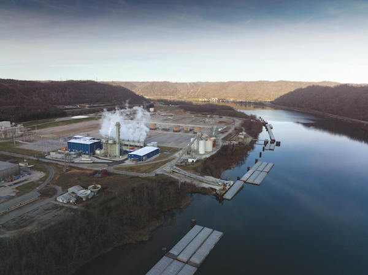

이런 뉴스가 무서운 까닭은 미국은 조용히 그러나 무서운 속도로 신재생 에너지로 전환하고 있습니다.

기술이 없어서도 아니고 땅덩어리가 좁아서도 아니고, 자원이 부족한 것도 아닌데 어마어마한 속도로 에너지 전환을 밀어붙이고 있습니다.

이런 에너지 전환이 완료된 후엔 뭘 할까요?

제 생각에는 환경을 무기로 여러가지 장벽을 쌓아올일 것입니다.

탄소세를 비롯한 온갖 장벽을 말이죠. 환경을 명분으로 한 사다리 걷어차기가 가능한 그런 장벽을 말이죠.

과연 그 전에 우리도 에너지 전환을 이룰 수 있을까요?

## 전력시장

### Wordcloud for Enerbility

[interactive chart not shown]

### 전력계통

<변동내역>

- 중앙급전발전기 : 태안IGCC 중앙급전발전기 전환[+346.3MW]
- 비중앙급전발전기 : 보광 태양광 발전소 신설 등[-473.0MW]*
- 한전 제출 PPA설비 자료 오류로 인하여 지난주 공표(’22.6.1 기준) 대비 -160.8MW/-859대 오차 수정

**best regards,**  
**J.H**

**Industry News?**  
매주 전력산업의 새로운 소식과 산업계 동향을 공유하는 뉴스레터입니다.  
Feedback은 언제라도 환영합니다.  
📫 junho.ahn@doosan.com

**END**